# Moving beyond linearity

10/22/2019

## Agenda

- Polynomial regression
- Step functions
- Regression splines
- Smoothing splines
- Generalized additive models

## Agenda

[figure not shown]

## Linear models: major cons

- Linear models are pretty much always *wrong*; if the truth is nonlinear, then the linear model will provide a biased estimate
- Linear models depend on which transformation of the data you use, e.g. \(x\) versus \(\log(x)\)
- Linear models do not estimate interactions among the predictors unless you explicitly build them in

## How to improve

- Last week, we saw that we can improve upon OLS using ridge and lasso regression by reducing the complexity of the model, and hence the variance of the estimates
- This week, we relax the linearity assumption while still attempting to maintain as much interpretability as possible

## Polynomial regression

## Adding non linear terms

A simple approach for incorporating non-linear associations in a linear model is to include transformed versions of the predictors in the model, e.g.

\[\text{mpg} = \beta_0 + \beta_1 \text{horsepower} + \beta_2 \text{horsepower}^2 + \varepsilon\]

We are predicting mpg using a non-linear function of horsepower, but it is still a linear model with \(X_1 = \text{horsepower}\) and \(X_2 = \text{horsepower}^2\).

- We can use standard linear regression software to estimate the parameters
- **Polynomial** regression: extending the linear model to accommodate non-linear relationships

## Adding non linear terms

\[y_i = \beta_0 + \beta_1 x_i + \beta_2 x_i^2 + \dots + \beta_d x_i^d + \varepsilon_i\]

- Not really interested in the coefficients; more interested in the fitted function values at any value \(x_0\), i.e. \[\hat{f} (x_0) = \hat{\beta}_0 + \hat{\beta}_1 x_0 + \hat{\beta}_2 x_0^2 + \dots + \hat{\beta}_d x_0^d\]
- Since \(\hat{f} (x_0)\) is a linear function of the \(\hat{\beta}\)’s, can get a simple expression for the pointwise variances \(\text{Var}[\hat{f} (x_0)]\) at any value \(x_0\)
- We either fix the degree \(d\) at some reasonably low value, or use cross-validation to choose \(d\)
- Can fit using `y ~ poly(x, degree = d)` in formula

## A note on confidence intervals

- Since \(\hat{f} (x_0)\) is a linear function of the \(\hat{\beta}\)’s, we can get a simple expression for the pointwise variances \(\text{Var}[\hat{f} (x_0)]\) at any value \(x_0\)

Can use `predict(fit, newdata = ..., se = T)` and then use the 2 standard deviation rule.

Caveat: polynomials have notorious tail behavior - very bad for extrapolation. This is due to the fact that the polynomial function is defined globally (fitted using all of the data).

## Adding non linear terms

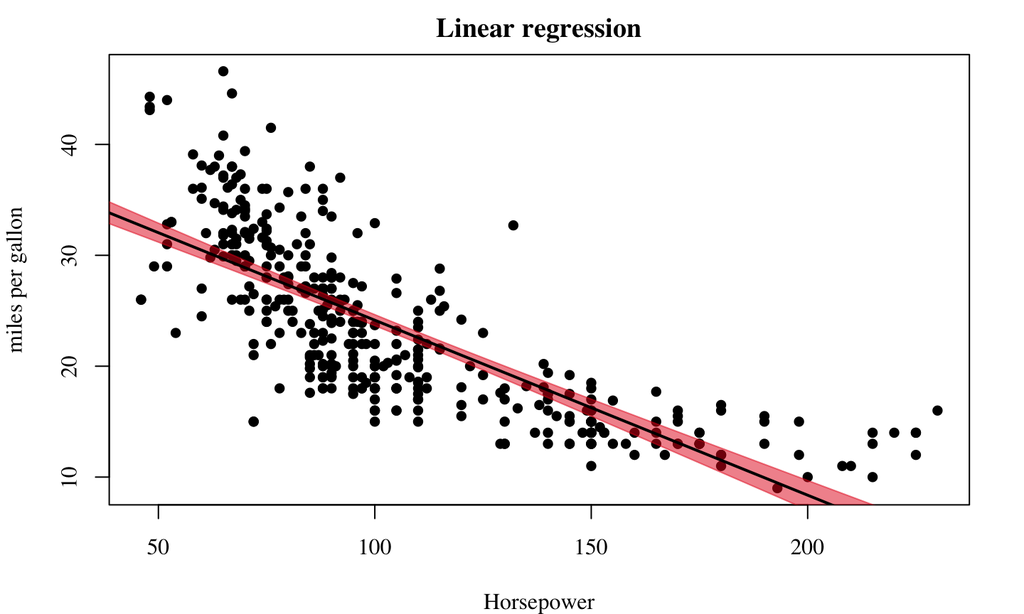

## Adding non linear terms

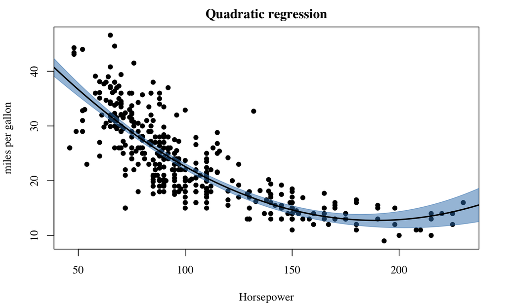

## Adding non linear terms

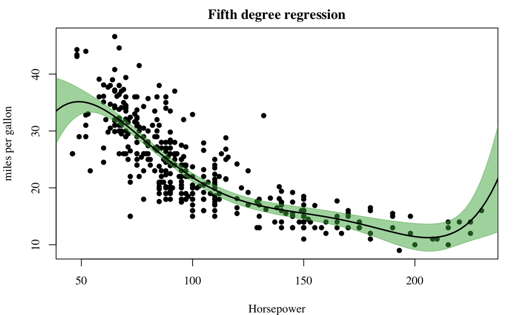

## Step Functions

## Step Functions

Another way of creating transformations of a variable: cut the variable into distinct regions.

In order to fit a step function we use the `cut()` function.

Given cutpoints \(c_1, c_2, c_3\) in the range of \(X\), we construct \(4\) dummy variables

We only use \(3\) of them (one is the baseline). In general, given \(K\) cutpoints there are \(K+1\) intervals and \(K\) dummy variables.

## Step Functions

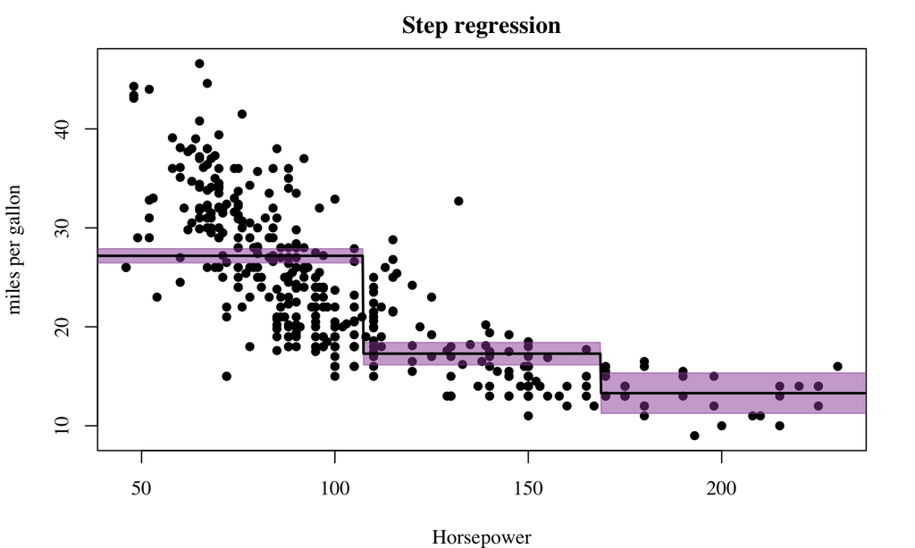

## Step Functions

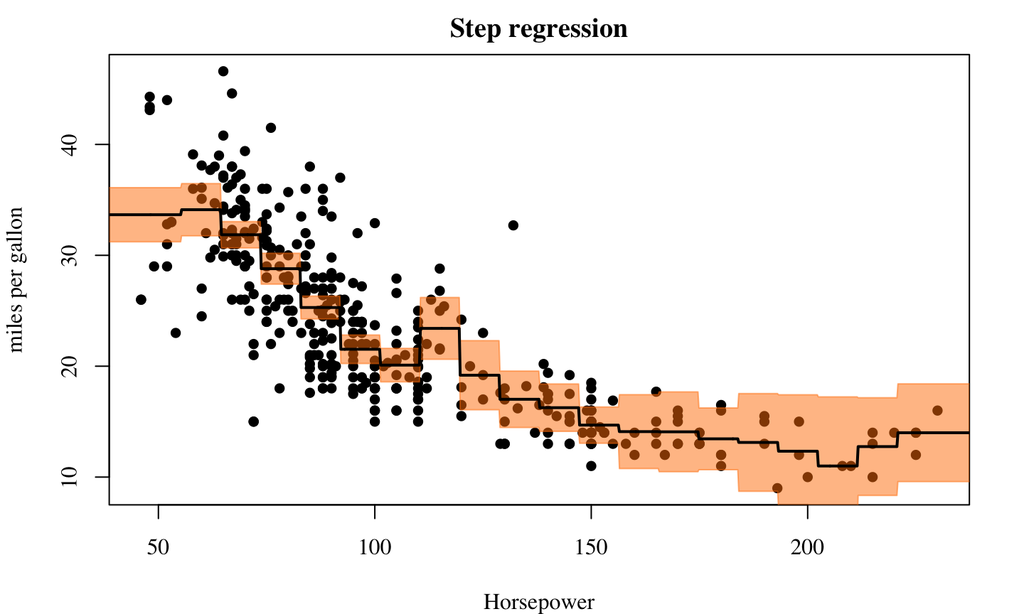

## Step Functions

- Only uses some datapoints in the estimation of each \(\beta_j\)
- Easy to work with: create a series of dummy variables representing each group
- Useful way of creating interactions that are easy to interpret, e.g. \[\mathbb{I}(horsepower \leq 150) \times \text{Speed}, \mathbb{I}(horsepower > 150) \times \text{Speed}\] would allow for different linear functions in each age category
- Choice of cutpoints or knots can be problematic. For creating nonlinearities, smoother alternatives such as splines are available

## Splines

## Spline approach

Let’s take the best of the two previous ideas:

- **smoothness** and flexibility, from polynomial regression
- **local support**, from step function approach
- Instead of a single polynomial in \(X\) over its whole domain, we can rather use different polynomials in regions defined by knots, e.g. \[y_i = \begin{cases} \beta_{01} + \beta_{11} x_i + \beta_{21} x_i^2 + \beta_{31} x_i^3 + \varepsilon_i, \quad &\text{if } x_i \leq c \\ \beta_{02} + \beta_{12} x_i + \beta_{22} x_i^2 + \beta_{32} x_i^3 + \varepsilon_i, \quad &\text{if } x_i > c \end{cases}\]
- Better to add constraints to the polynomials, e.g. continuity
- Splines have the “maximum” amount of continuity

## Two distinct polynomials

Two distinct \(3^{rd}\) degree polynomials. How many degrees of freedom (parameters)?

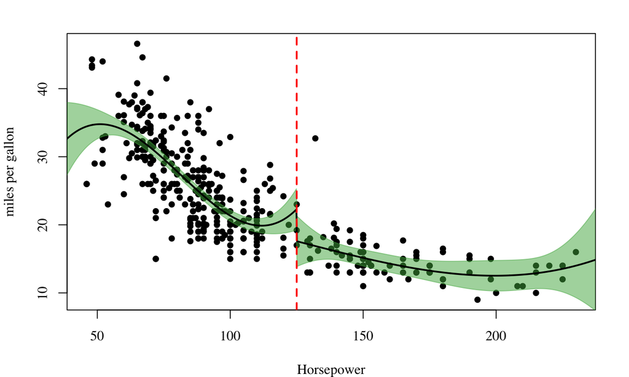

## Two distinct polynomials: continuity

Two distinct \(3^{rd}\) degree polynomials with continuity. How many degrees of freedom (parameters)?

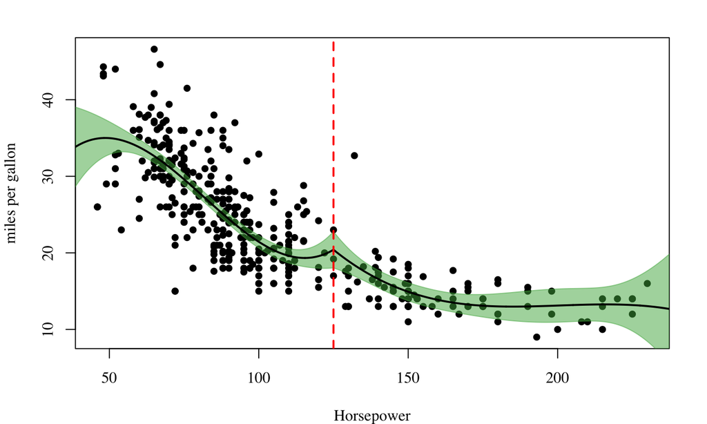

## Splines

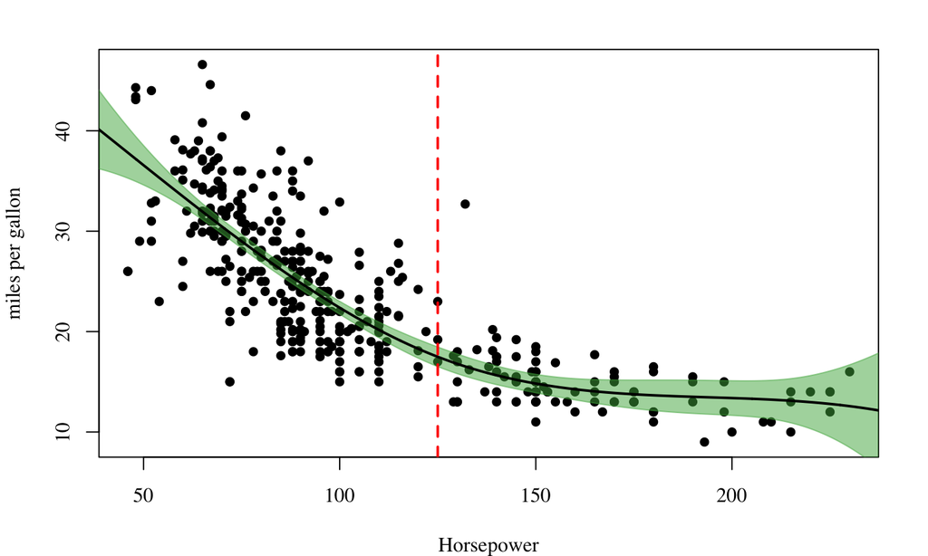

## Linear splines

A linear spline with knots at \(\xi_k, k = 1,2,\dots, K\) is a piecewise linear polynomial continuous at each knot. We can represent this model as \[y_i = \beta_0 + \beta_1 b_1(x_i)+ \beta_2 b_2(x_i)+ \dots + \beta_{K+1} b_{K+1}(x_i) + \varepsilon_i\]

where the \(b_k\) are basis functions (**truncated power** basis) \[\begin{aligned} &b_1(x_i) = x_i \\ &b_{k+1}(x_i)=(x_i - \xi_k)_{+}, \quad k = 1,2,\dots,K \end{aligned}\] Here the \((\dots)_{+}\) means positive part, i.e.

\[(x_i - \xi_k)_{+} = \begin{cases} x_i - \xi_k & \text{if } x_i > \xi_k \\ 0 & \text{otherwise} \end{cases}\]

## Linear splines

[figure not shown]

## Cubic splines

A cubic spline with knots at \(\xi_k, k = 1,2,\dots, K\) is a piecewise **cubic** polynomial with continuous derivatives up to order 2 at each knot. We can represent this model as \[y_i = \beta_0 + \beta_1 b_1(x_i)+ \beta_2 b_2(x_i)+ \dots + \beta_{K+3} b_{K+3}(x_i) + \varepsilon_i\]

where the \(b_k\) are basis functions \[\begin{aligned} &b_1(x_i) = x_i \\ &b_2(x_i) = x_i^2 \\ &b_3(x_i) = x_i^3 \\ &b_{k+3}(x_i)=(x_i - \xi_k)^{3}_{+}, \quad k = 1,2,\dots,K \end{aligned}\]

## Cubic splines

[figure not shown]

## Equivalent representation

- Since the space of spline functions of a particular order and knot sequence is a **vector space**, there are many equivalent bases for representing them (just as there are for ordinary polynomials)
- While the truncated power basis is conceptually simple, it is not too attractive numerically: powers of large numbers can lead to severe rounding problems
- In practice, we often use another basis: the B-spline basis, which allows for efficient computations even when the number of knots \(K\) is large (each basis function has a **local support**)

\[\hat{y}_i = \beta_0 + \beta_1 b_1(x_i)+ \beta_2 b_2(x_i)+ \dots + \beta_{K+3} b_{K+3}(x_i)\]

In `R`, we can simply fit a “linear” model on the spline basis!

`fit <- lm(Y2 ~ bs(X, df = 10, degree = 3))`

## Linear B-splines

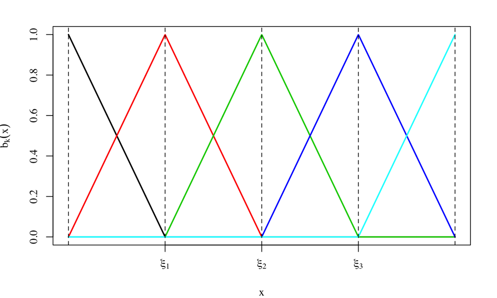

## Cubic B-splines

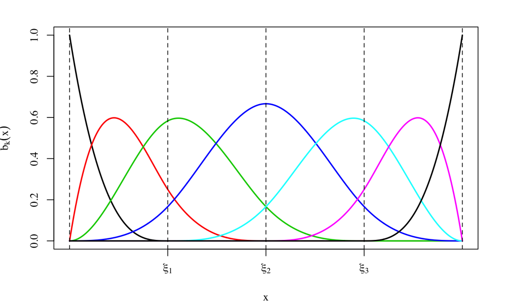

## Example of fit

\[\hat{f}(x) = \hat{\beta}_0 + \hat{\beta}_1 b_1(x)+ \hat{\beta}_2 b_2(x_i)+ \dots + \hat{\beta}_{K+3} b_{K+3}(x)\]

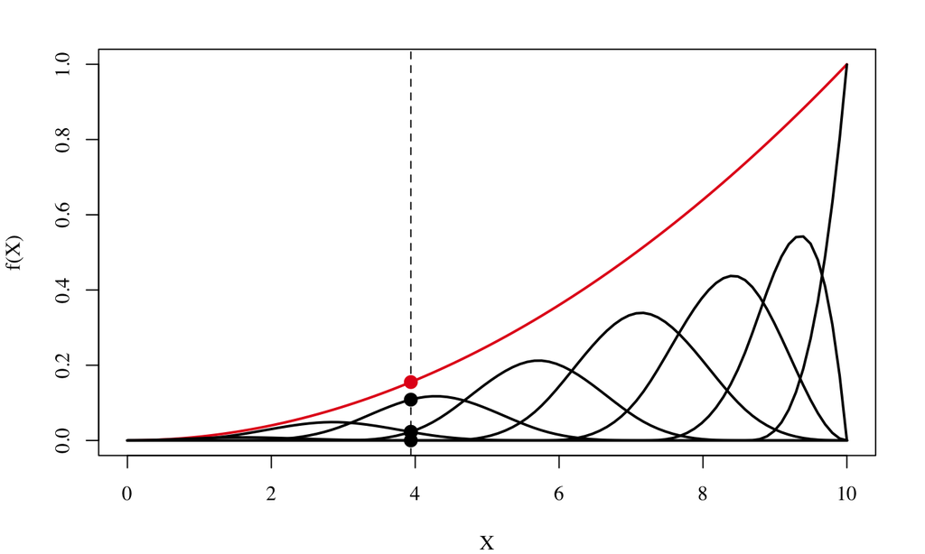

## Example of fit

\[\hat{f}(x) = \hat{\beta}_0 + \hat{\beta}_1 b_1(x)+ \hat{\beta}_2 b_2(x_i)+ \dots + \hat{\beta}_{K+3} b_{K+3}(x)\]

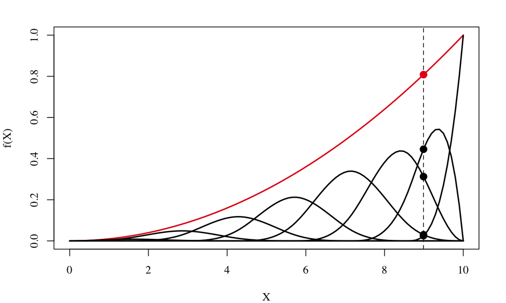

## Example of fit

\[\hat{f}(x) = \hat{\beta}_0 + \hat{\beta}_1 b_1(x)+ \hat{\beta}_2 b_2(x_i)+ \dots + \hat{\beta}_{K+3} b_{K+3}(x)\]

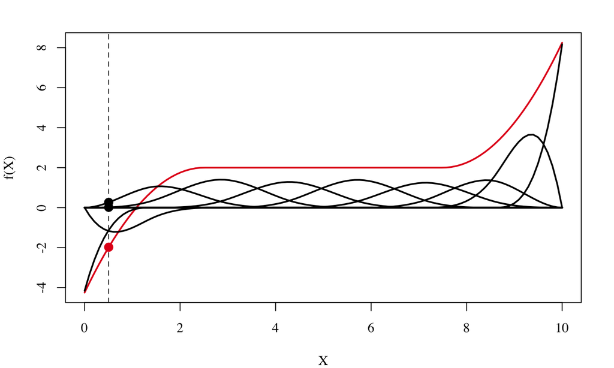

## Example of fit

\[\hat{f}(x) = \hat{\beta}_0 + \hat{\beta}_1 b_1(x)+ \hat{\beta}_2 b_2(x_i)+ \dots + \hat{\beta}_{K+3} b_{K+3}(x)\]

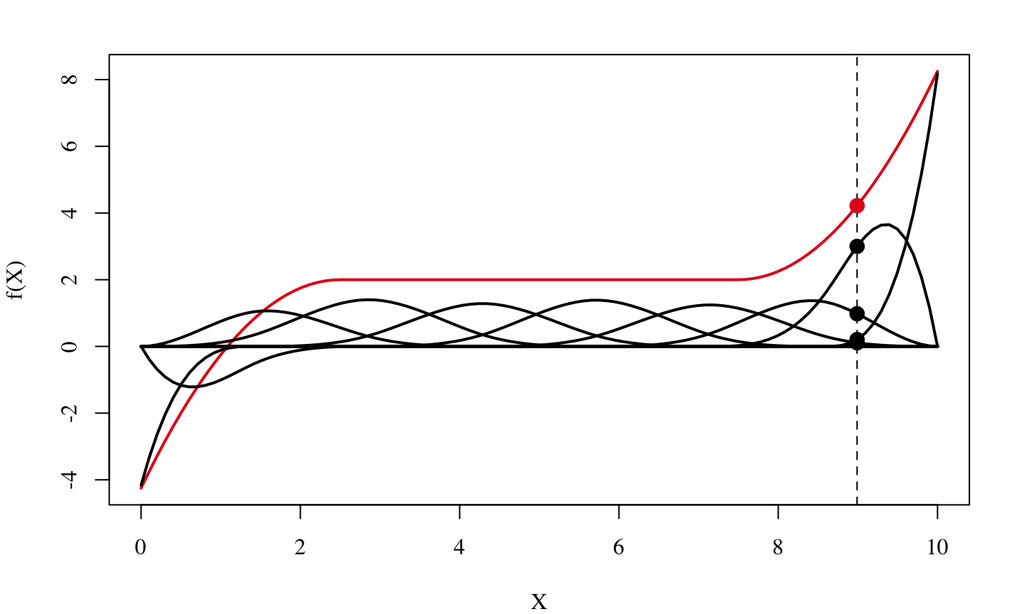